# Histograms with ggplot2

Let's go over how to create histograms with ggplot2. Refer to the video for the full explanation! Also a quick note, we are going to be showing a lot of what ggplot *can* do, but **not** what you *should* do!

## Load Data

We'll use the movie dataset that comes with ggplot:

```r
library(ggplot2)
df <- movies <- movies[sample(nrow(movies), 1000), ]
```

```r
head(df)
```

|  | title | year | length | budget | rating | votes | r1 | r2 | r3 | r4 | r5 | r6 | r7 | r8 | r9 | r10 | mpaa | Action | Animation | Comedy | Drama | Documentary | Romance | Short |
| --- | --- | --- | --- | --- | --- | --- | --- | --- | --- | --- | --- | --- | --- | --- | --- | --- | --- | --- | --- | --- | --- | --- | --- | --- |
| 21569 | Gunan il guerriero | 1983 | 81 | NA | 2 | 38 | 44.5 | 14.5 | 4.5 | 14.5 | 14.5 | 0 | 4.5 | 4.5 | 4.5 | 4.5 |  | 1 | 0 | 0 | 0 | 0 | 0 | 0 |
| 39820 | Phantom Brother | 1988 | 92 | NA | 2 | 10 | 45.5 | 14.5 | 0 | 0 | 0 | 24.5 | 14.5 | 0 | 0 | 14.5 |  | 0 | 0 | 0 | 0 | 0 | 0 | 0 |
| 47662 | Snow | 1996 | 81 | NA | 7.2 | 10 | 0 | 0 | 14.5 | 0 | 0 | 44.5 | 14.5 | 24.5 | 0 | 24.5 |  | 0 | 0 | 0 | 1 | 0 | 0 | 0 |
| 41080 | Prelude | 2000 | 6 | NA | 6.3 | 18 | 4.5 | 0 | 0 | 14.5 | 4.5 | 0 | 24.5 | 24.5 | 4.5 | 24.5 |  | 0 | 0 | 0 | 0 | 0 | 0 | 1 |
| 58741 | Zwaarmoedige verhalen voor bij de centrale verwarming | 1975 | 95 | NA | 5 | 27 | 14.5 | 0 | 0 | 4.5 | 14.5 | 14.5 | 14.5 | 14.5 | 14.5 | 24.5 |  | 0 | 0 | 1 | 1 | 0 | 0 | 0 |
| 47430 | Sleepy-Time Tom | 1951 | 7 | NA | 6.7 | 32 | 0 | 0 | 0 | 14.5 | 4.5 | 4.5 | 24.5 | 14.5 | 24.5 | 4.5 |  | 0 | 1 | 1 | 0 | 0 | 0 | 1 |

## Using qplot()

**Basics**

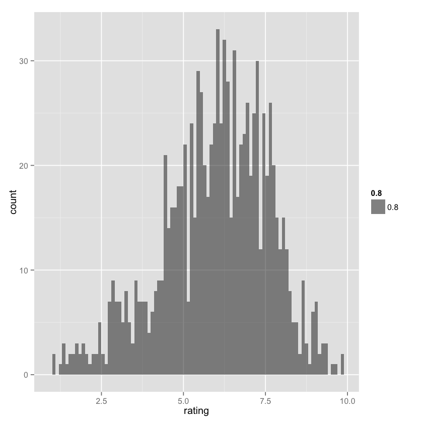

```r
qplot(rating,data=df,geom='histogram',binwidth=0.1,alpha=0.8)
```

## Using ggplot()

Let's see how we can really expand on this by using ggplot! They syntax starts off with the base plot:

```r
# ggplot(data, aesthetics)
pl <- ggplot(df,aes(x=rating))
```

```
stat_bin: binwidth defaulted to range/30. Use 'binwidth = x' to adjust this.
```

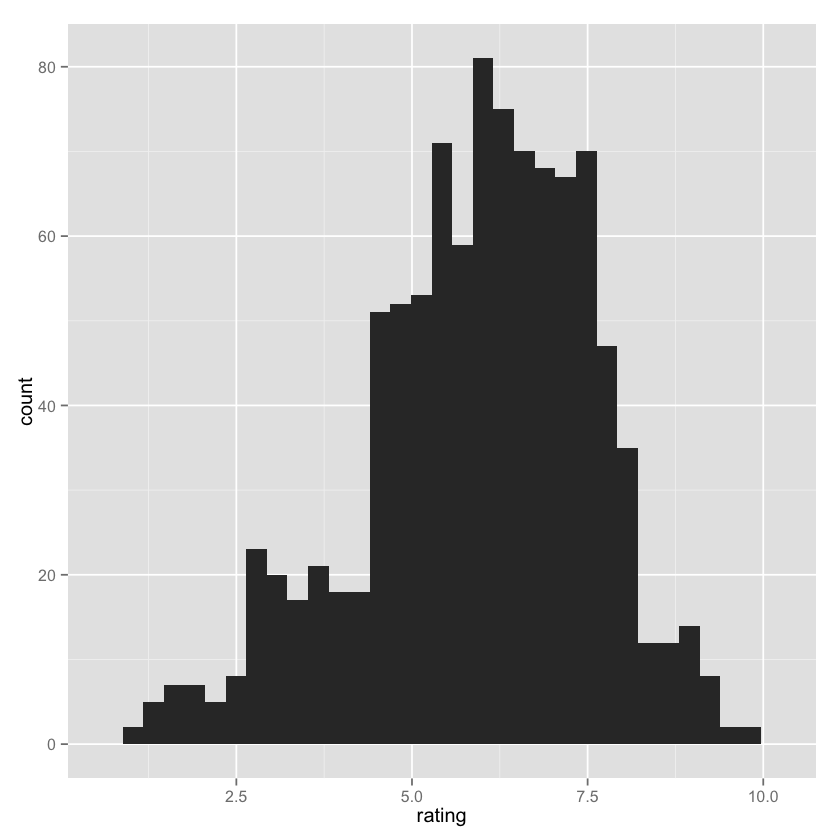

```r
# Add Histogram Geometry
pl + geom_histogram()
```

## Adding Color

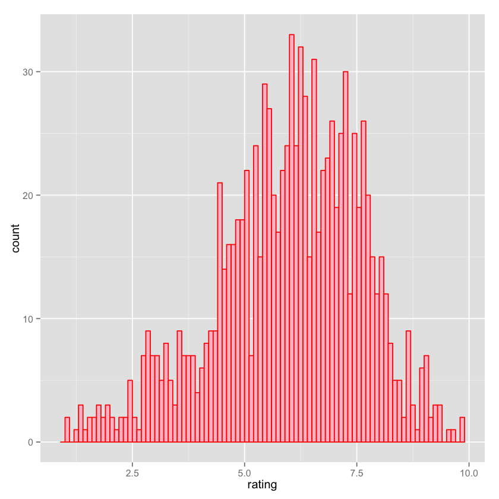

```r
pl <- ggplot(df,aes(x=rating))
pl + geom_histogram(binwidth=0.1,color='red',fill='pink')
```

## Adding Labels

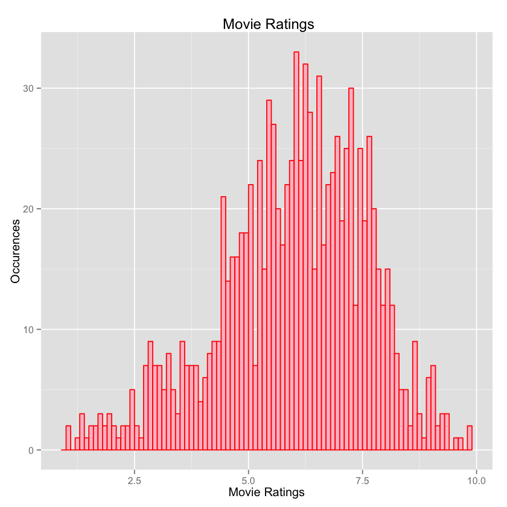

```r
pl <- ggplot(df,aes(x=rating))
pl + geom_histogram(binwidth=0.1,color='red',fill='pink') + xlab('Movie Ratings')+ ylab('Occurences') + ggtitle(' Movie Ratings')
```

## Change Alpha (Transparency)

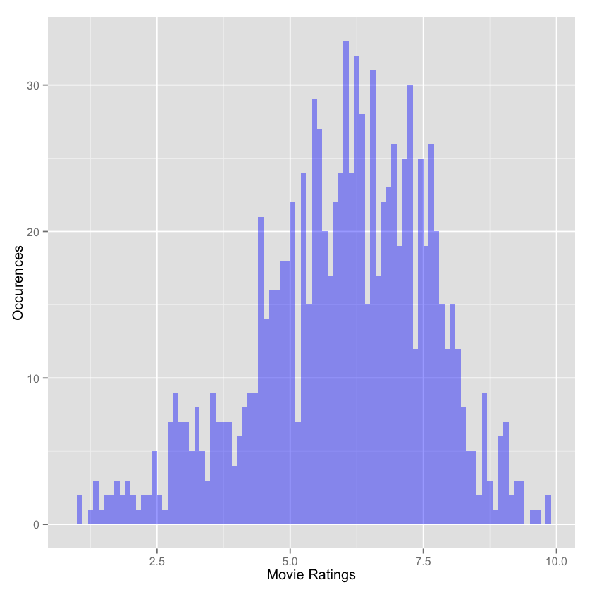

```r
pl <- ggplot(df,aes(x=rating))
pl + geom_histogram(binwidth=0.1,fill='blue',alpha=0.4) + xlab('Movie Ratings')+ ylab('Occurences')
```

## Linetypes

We have the options: "blank", "solid", "dashed", "dotted", "dotdash", "longdash", and "twodash". You would never really use these with a histogram, but just to show your options:

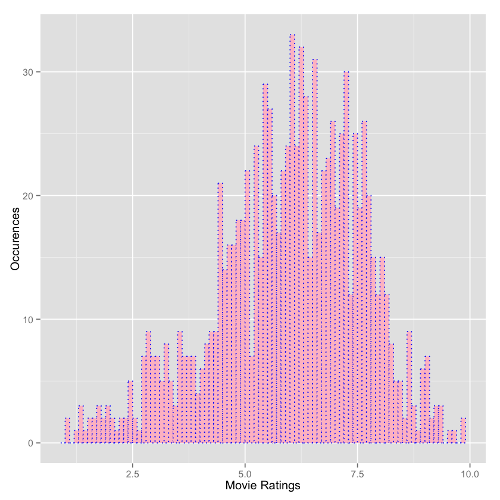

```r
pl <- ggplot(df,aes(x=rating))
pl + geom_histogram(binwidth=0.1,color='blue',fill='pink',linetype='dotted') + xlab('Movie Ratings')+ ylab('Occurences')
```

## Advanced Aesthetics

We can add a **aes()** argument to the geom_histogram for some more advanced features. We won't go too deep into these, but ggplot gives you the ability to edit color and fill scales.

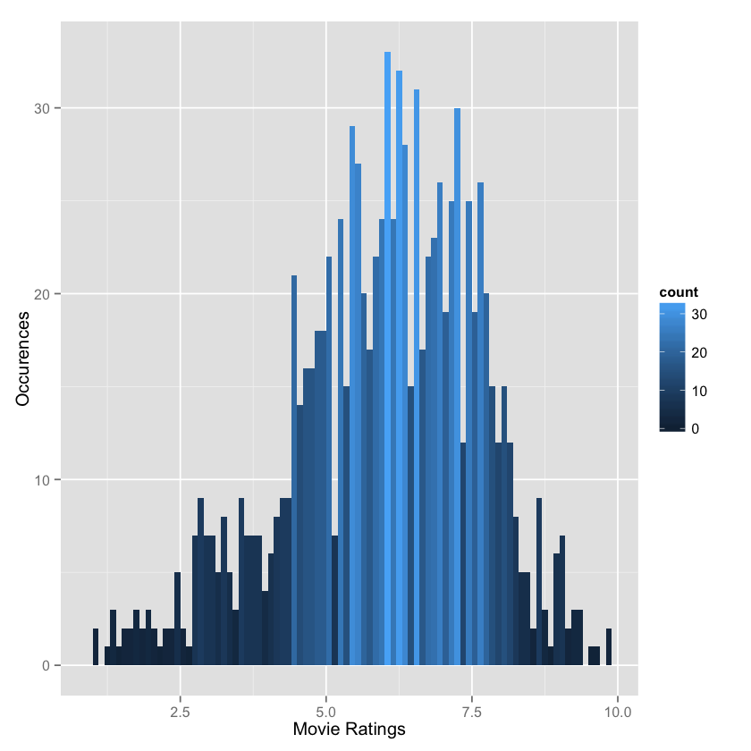

```r
# Adding Labels
pl <- ggplot(df,aes(x=rating))
pl + geom_histogram(binwidth=0.1,aes(fill=..count..)) + xlab('Movie Ratings')+ ylab('Occurences')
```

You can further edit this by adding the **scale_fill_gradient()** function to your ggplot objects:

```r
# Adding Labels
pl <- ggplot(df,aes(x=rating))
pl2 <- pl + geom_histogram(binwidth=0.1,aes(fill=..count..)) + xlab('Movie Ratings')+ ylab('Occurences')
```

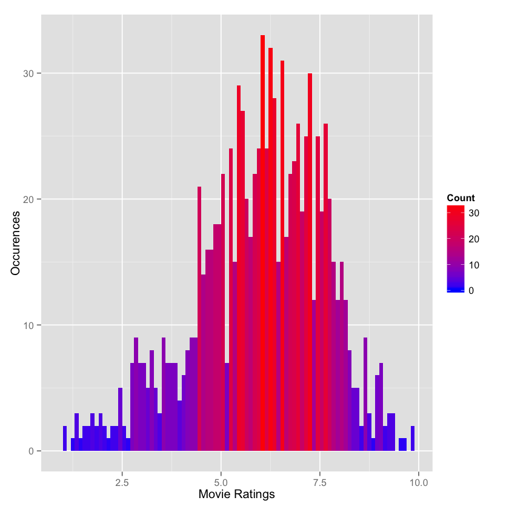

```r
# scale_fill_gradient('Label',low=color1,high=color2)
pl2 + scale_fill_gradient('Count',low='blue',high='red')
```

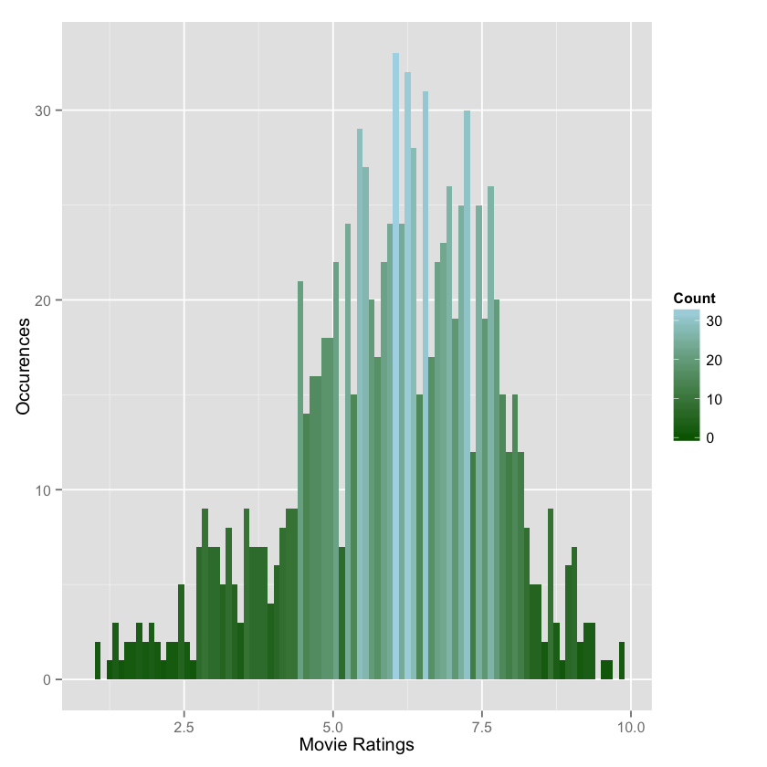

```r
# scale_fill_gradient('Label',low=color1,high=color2)
pl2 + scale_fill_gradient('Count',low='darkgreen',high='lightblue')
```

## Adding density plot

You can add a [kernel density estimation plot](https://en.wikipedia.org/wiki/Kernel_density_estimation)

```
stat_bin: binwidth defaulted to range/30. Use 'binwidth = x' to adjust this.
```

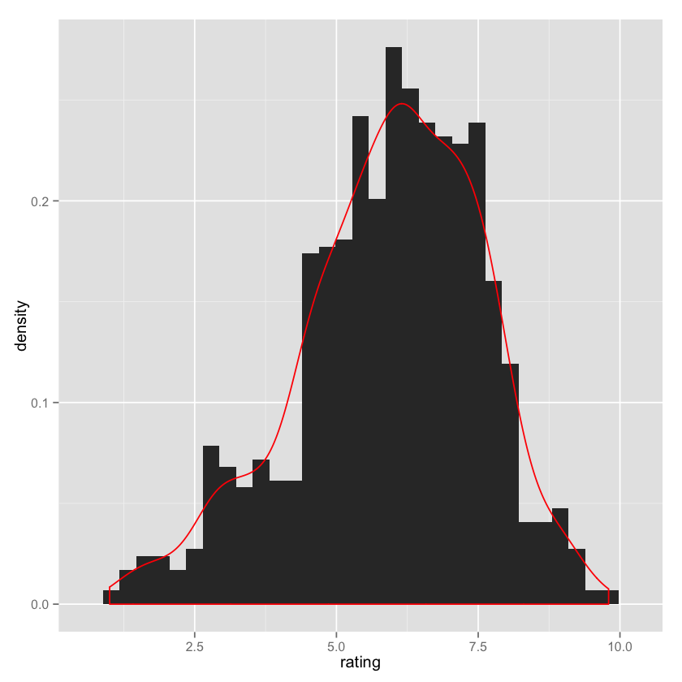

```r
# Adding Labels
pl <- ggplot(df,aes(x=rating))
pl + geom_histogram(aes(y=..density..)) + geom_density(color='red')
```

Alright! That's all for now concerning histograms. We've shown that ggplot has amazing customization capabilities, however it definitely takes time to get used to!